# Data 607 Final Project

Coco Donovan

2023-05-15

### Introduction:

I chose to have the focus of my analysis be police incident reports from the City of San Francisco Police Department. My intention was to include analysis of crime clearance statistics, and unfortunately that is not possible and I will get into that dynamic a little during my presentation. Ultimately, I chose to conduct an analysis over the years of crime and reports of crime.

### Limitations:

There is no readily available data for before 2003, so I cannot make quantitative statements from my own analysis of crime trends from before 2003 (I would love to based on reporting I have seen; however that would not be my own work).

There are two different data sets; one from 2003-2018 and another from 2018-current. From this change in data sources has come a difference in values for the same variables (this makes certain forms of analysis difficult to produce).

### Necessary Packages

```r
library(httr)
library(jsonlite)
library(ggplot2)
library(dplyr)
library(readr)
library(tidyverse)
```

### Police Incident Data: 2003 - 2017

```r
old_police_files  <- list.files(pattern = '^Police_Data_....\\.csv')

old_police_tables <- lapply(old_police_files, read.csv, header = TRUE)

old_police_data <- do.call(rbind , old_police_tables)
```

### Police Incident Data: 2018 - Current

```r
present_police_files  <- list.files(pattern = 'Present_Police_Data_....\\.csv')

present_police_tables <- lapply(present_police_files, read.csv, header = TRUE)

present_police_data <- do.call(rbind , present_police_tables)
```

### SF Yearly Population

```r
sf_pop <- read.csv('SF_POP.csv')

sf_pop$Population <- 1000 * sf_pop$Population

sf_pop <- sf_pop %>%
  separate(Year, c('year', 'month', 'date'), '-') %>%
  select(year, Population)

sf_pop$year <- as.integer(sf_pop$year)

sf_pop <- sf_pop %>%
  filter(year >= 2003)
```

### Joining New and Old Incident Counts, Reports, and the ratio of the two:

```r
old_police_data <- old_police_data %>%
  separate(Date, c("month", "day","year"), "/")

old_police_data$year <- as.integer(old_police_data$year)

old_counts_and_incidents <- old_police_data %>%
  group_by(year) %>%
  summarize(count_reports = as.double(n()), count_incidents = as.double(length(unique(IncidntNum))))

new_counts_and_incidents <- present_police_data %>%
  rename('year' = 'Incident.Year') %>%
  group_by(year) %>%
  summarize(count_reports = as.double(n()), count_incidents = as.double(length(unique(Incident.Number))))

counts_and_incidents <- rbind(new_counts_and_incidents, old_counts_and_incidents)

counts_and_incidents <- counts_and_incidents %>%
  group_by(year) %>%
  mutate(ratio = count_reports/count_incidents) %>%
  arrange(desc(year))

knitr::kable(counts_and_incidents)
```

| year | count_reports | count_incidents | ratio |
| --- | --- | --- | --- |
| 2023 | 44748 | 32720 | 1.367604 |
| 2022 | 134843 | 98483 | 1.369201 |
| 2021 | 128775 | 93640 | 1.375214 |
| 2020 | 118313 | 84351 | 1.402627 |
| 2019 | 148272 | 108330 | 1.368707 |
| 2018 | 152707 | 111528 | 1.369226 |
| 2017 | 149487 | 119633 | 1.249546 |
| 2016 | 145994 | 115390 | 1.265222 |
| 2015 | 151459 | 120623 | 1.255640 |
| 2014 | 144844 | 114664 | 1.263204 |
| 2013 | 147664 | 113518 | 1.300798 |
| 2012 | 135464 | 106708 | 1.269483 |
| 2011 | 126713 | 98883 | 1.281444 |
| 2010 | 127758 | 99311 | 1.286444 |
| 2009 | 134309 | 105833 | 1.269065 |
| 2008 | 135242 | 111653 | 1.211271 |
| 2007 | 131771 | 109297 | 1.205623 |
| 2006 | 131856 | 112825 | 1.168677 |
| 2005 | 137048 | 112695 | 1.216096 |
| 2004 | 142054 | 113110 | 1.255893 |
| 2003 | 142803 | 114538 | 1.246774 |

### Visualizations: Incidents Over Time

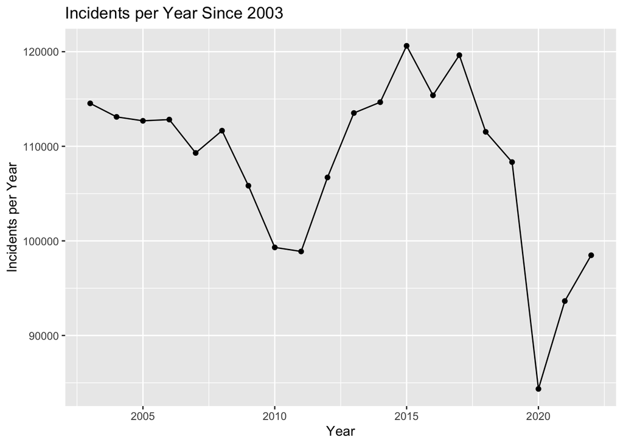

```r
# I did not include 2023 just yet, because the year is only a about 1/3 of the
# way over and would not contribute to reliable comparisions for raw counts

counts_and_incidents_no_2023 <- subset(counts_and_incidents, year != 2023)

ggplot(counts_and_incidents_no_2023, aes(x= year, y= count_incidents)) +
  geom_point() +
  geom_line() +
  labs(x = 'Year', y = 'Incidents per Year', title = 'Incidents per Year Since 2003')
```

### Visualization: Ratio of reports vs acutal incidents

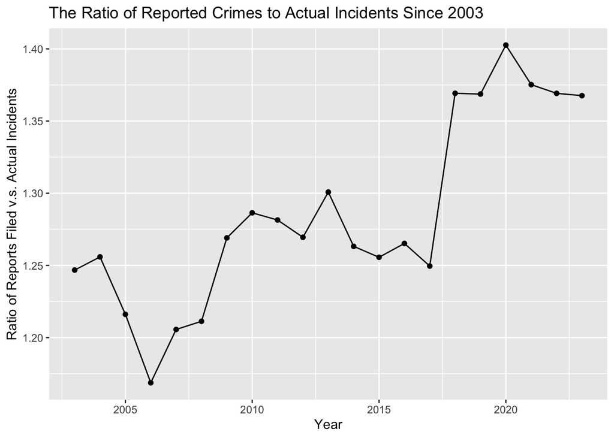

```r
ggplot(counts_and_incidents, aes(x= year, y= ratio)) +
  geom_point() +
  geom_line() +
  labs(x = 'Year', y = 'Ratio of Reports Filed v.s. Actual Incidents', title = 'The Ratio of Reported Crimes to Actual Incidents Since 2003')
```

### Adding population to counts and incidents

```r
years_and_counts <- full_join(sf_pop, counts_and_incidents, by = 'year')
```

### Crime per 100K

```r
years_and_counts <- years_and_counts %>%
  mutate(reports_per_100k = 100000 * count_reports/Population, incidents_per_100k = 100000 * count_incidents/Population) %>%
  arrange(desc(year))

knitr::kable(years_and_counts)
```

| year | Population | count_reports | count_incidents | ratio | reports_per_100k | incidents_per_100k |
| --- | --- | --- | --- | --- | --- | --- |
| 2023 | NA | 44748 | 32720 | 1.367604 | NA | NA |
| 2022 | 808437 | 134843 | 98483 | 1.369201 | 16679.47 | 12181.90 |
| 2021 | 811253 | 128775 | 93640 | 1.375214 | 15873.59 | 11542.64 |
| 2020 | 870393 | 118313 | 84351 | 1.402627 | 13593.06 | 9691.14 |
| 2019 | 878826 | 148272 | 108330 | 1.368707 | 16871.60 | 12326.67 |
| 2018 | 879676 | 152707 | 111528 | 1.369226 | 17359.46 | 12678.30 |
| 2017 | 877471 | 149487 | 119633 | 1.249546 | 17036.12 | 13633.84 |
| 2016 | 871343 | 145994 | 115390 | 1.265222 | 16755.06 | 13242.78 |
| 2015 | 863237 | 151459 | 120623 | 1.255640 | 17545.47 | 13973.34 |
| 2014 | 850918 | 144844 | 114664 | 1.263204 | 17022.09 | 13475.33 |
| 2013 | 839695 | 147664 | 113518 | 1.300798 | 17585.43 | 13518.96 |
| 2012 | 828963 | 135464 | 106708 | 1.269483 | 16341.38 | 12872.47 |
| 2011 | 815694 | 126713 | 98883 | 1.281444 | 15534.38 | 12122.56 |
| 2010 | 805519 | 127758 | 99311 | 1.286444 | 15860.33 | 12328.82 |
| 2009 | 815184 | 134309 | 105833 | 1.269065 | 16475.91 | 12982.71 |
| 2008 | 807904 | 135242 | 111653 | 1.211271 | 16739.86 | 13820.08 |
| 2007 | 799185 | 131771 | 109297 | 1.205623 | 16488.17 | 13676.06 |
| 2006 | 786187 | 131856 | 112825 | 1.168677 | 16771.58 | 14350.91 |
| 2005 | 777835 | 137048 | 112695 | 1.216096 | 17619.16 | 14488.29 |
| 2004 | 773556 | 142054 | 113110 | 1.255893 | 18363.76 | 14622.08 |
| 2003 | 775663 | 142803 | 114538 | 1.246774 | 18410.44 | 14766.46 |

### Visualization: Crime Incidents per 100k

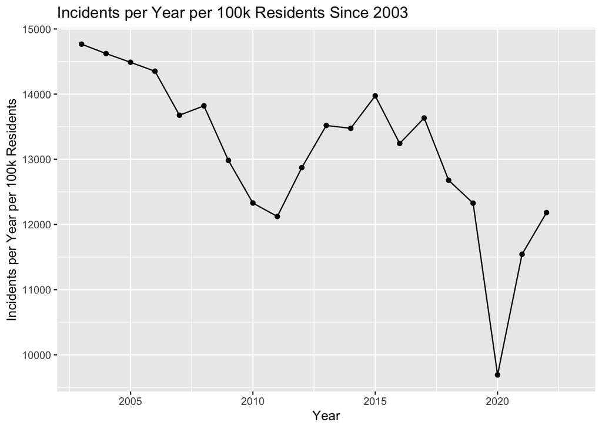

```r
ggplot(years_and_counts, aes(x= year, y= incidents_per_100k)) +
  geom_point() +
  geom_line() +
  labs(x = 'Year', y = 'Incidents per Year per 100k Residents', title = 'Incidents per Year per 100k Residents Since 2003')
```

### Arrest Rate Rate

This is not possible for over time comparison and that has to do with how SF records “Resolutions” to incidents. There is no easily accessible (I could not find any after scouring SFPD’s website and SF City and County Documentation) documentation on what each resolution type meant for the older data, and then the classifications were changed with no explanation. Due to this lack of transparency, it is difficult to track crime clearance rates over time. It does seem that this is data that does exist internally and it is not open sourced.

```r
new_outcomes <- present_police_data %>%
  group_by(Resolution) %>%
  summarize(counts = n())

unique(new_outcomes$Resolution)
```

```
## [1] "Cite or Arrest Adult" "Exceptional Adult"    "Open or Active"
## [4] "Unfounded"
```

```r
old_outcomes <- old_police_data %>%
  group_by(Resolution) %>%
  summarize(count = n())

unique(tolower(old_outcomes$Resolution))
```

```
##  [1] "arrest, booked"
##  [2] "arrest, cited"
##  [3] "complainant refuses to prosecute"
##  [4] "district attorney refuses to prosecute"
##  [5] "exceptional clearance"
##  [6] "located"
##  [7] "none"
##  [8] "not prosecuted"
##  [9] "prosecuted by outside agency"
## [10] "prosecuted for lesser offense"
## [11] "psychopathic case"
## [12] "unfounded"
```

### Incident Code Crosswalk:

I am going to have to do some manual work to make a full cross walk because if just use the DataSF crosswalk that leaves me with about 6800 obersvations without a crime category. Not to mention, the missing crime categories occur more often in the earlier years which would slightly skew results in the direction of the dangerous SF narrative.

```r
# This incident codes crosswalk comes from DataSF and using it leads to missing
# crime categories. Essentially, this crosswalk is not sufficient and needs to be
# improved and the process will unfortunately be largely manual.

#incident_codes <- jsonlite::fromJSON('https://data.sfgov.org/resource/ci9u-8awy.json?$limit=1012')

#incident_codes$inc_code <- as.integer(incident_codes$inc_code)

#incident_codes <- incident_codes %>%
#  rename(Incident.Code = inc_code, Category = category, Subcategory = subcategory)

incident_codes <- present_police_data %>%
  select(Incident.Code, Incident.Category) %>%
  unique()

# I could continue this process, but this gets the number of observations missing
# a category down to a little less the 800, which is significantly better than the
# 6793 observations missing a category when you use DataSF's proprietary crosswalk
# and truthfully this is a bit of tedious process.

row1 = c(Incident.Code = 11010, Incident.Category = 'Stolen Property')
row2 = c(Incident.Code = 28090, Incident.Category = 'Vandalism')
row3 = c(Incident.Code = 30090, Incident.Category = 'Other Miscellaneous')
row4 = c(Incident.Code = 0, Incident.Category = 'Other Miscellaneous')
row5 = c(Incident.Code = 6311, Incident.Category = 'Larceny Theft')
row6 = c(Incident.Code = 16644, Incident.Category = 'Drug Violation')

incident_codes <- rbind(incident_codes, row1, row2, row3, row4, row5, row6)

incident_codes$Incident.Code <- as.integer(incident_codes$Incident.Code)

# Combined Drug Offense and Drug Violation into one category

incident_codes$Incident.Category[incident_codes$Incident.Category == 'Drug Offense'] <- 'Drug Violation'

# lumped the blank category in with miscellaneous

incident_codes$Incident.Category[incident_codes$Incident.Category == ''] <- 'Other Miscellaneous'

# The manual process of finding the missing categories:

old_incident_codes <- old_police_data %>%
  select(Incident.Code, Category) %>%
  filter()

unique(old_incident_codes$Category)
```

```
##  [1] "MISSING PERSON"              "WARRANTS"
##  [3] "DRUG/NARCOTIC"               "ASSAULT"
##  [5] "LARCENY/THEFT"               "SECONDARY CODES"
##  [7] "FORGERY/COUNTERFEITING"      "NON-CRIMINAL"
##  [9] "ROBBERY"                     "OTHER OFFENSES"
## [11] "VEHICLE THEFT"               "SUSPICIOUS OCC"
## [13] "WEAPON LAWS"                 "EMBEZZLEMENT"
## [15] "FRAUD"                       "KIDNAPPING"
## [17] "VANDALISM"                   "BURGLARY"
## [19] "DISORDERLY CONDUCT"          "LOITERING"
## [21] "SEX OFFENSES, FORCIBLE"      "DRUNKENNESS"
## [23] "TRESPASS"                    "BAD CHECKS"
## [25] "STOLEN PROPERTY"             "PROSTITUTION"
## [27] "DRIVING UNDER THE INFLUENCE" "ARSON"
## [29] "EXTORTION"                   "BRIBERY"
## [31] "LIQUOR LAWS"                 "SUICIDE"
## [33] "GAMBLING"                    "PORNOGRAPHY/OBSCENE MAT"
## [35] "SEX OFFENSES, NON FORCIBLE"  "RECOVERED VEHICLE"
## [37] "TREA"
```

```r
is_it_in_old <- old_incident_codes %>%
  filter(Incident.Code == 'insert integer value Incident.Code')

categories <- unique(incident_codes$Incident.Category)
```

### Analysis of Crime Type:

```r
type_old <- old_police_data %>%
  select(year, IncidntNum, Incident.Code) %>%
  rename(Incident.Number = IncidntNum, Incident.Year = year)

type_new <- present_police_data %>%
  select(Incident.Year, Incident.Number, Incident.Code)

total_type <- bind_rows(type_old, type_new)

incidents_with_types <- left_join(total_type, incident_codes)
# -------------------------------
# Checking the missing values:

dist_missing_types <- incident_codes %>%
  filter(is.na(Incident.Category)) %>%
  #group_by(Incident.Year) %>%
  summarise(n())

missing_types <- incident_codes %>%
  filter(is.na(Incident.Category)) %>%
  group_by(Incident.Code) %>%
  summarize(n())
# ------------------------------

counts_by_category <- incidents_with_types %>%
  group_by(Incident.Year, Incident.Category) %>%
  summarise(count_reports = as.double(n()), count_incidents = as.double(length(unique(Incident.Number)))) %>%
  mutate(ratio = count_reports/count_incidents) %>%
  arrange(Incident.Year, desc(count_reports))
counts_by_category <- counts_by_category %>%
  rename(year = Incident.Year)

year_pop_counts_categories <- full_join(sf_pop, counts_by_category, by = 'year')

counts_by_category <- year_pop_counts_categories %>%
  group_by(year, Incident.Category) %>%
  mutate(incidents_per_100k = 100000 * count_incidents/Population) %>%
  arrange(year, desc(count_reports))
```

### Visualization: Drug Violations

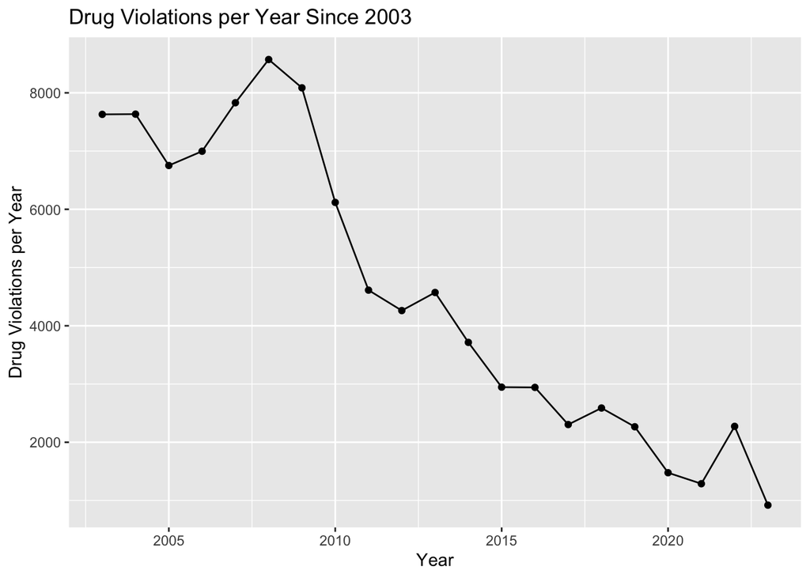

```r
counts_by_category_drug_violations <- counts_by_category %>%
  filter(Incident.Category == 'Drug Violation')

# Overall Incidents over Time

ggplot(counts_by_category_drug_violations, aes(x= year, y= count_incidents)) +
  geom_point() +
  geom_line() +
  labs(x = 'Year', y = 'Drug Violations per Year', title = 'Drug Violations per Year Since 2003')
```

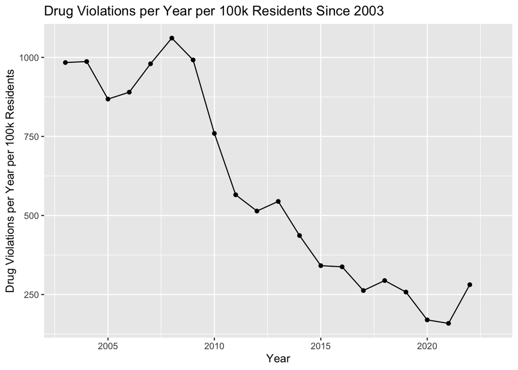

```r
# Incidents Per 100k

ggplot(counts_by_category_drug_violations, aes(x= year, y= incidents_per_100k)) +
  geom_point() +
  geom_line() +
  labs(x = 'Year', y = 'Drug Violations per Year per 100k Residents', title = 'Drug Violations per Year per 100k Residents Since 2003')
```

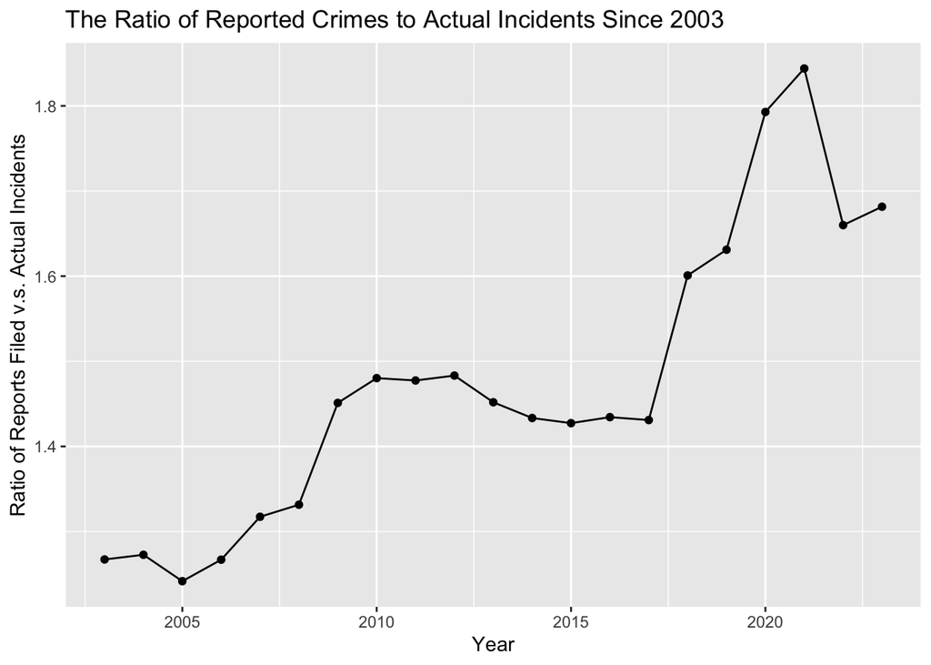

```r
# Ratio of Reports vs Actual Incidents

ggplot(counts_by_category_drug_violations, aes(x= year, y= ratio)) +
  geom_point() +
  geom_line() +
  labs(x = 'Year', y = 'Ratio of Reports Filed v.s. Actual Incidents', title = 'The Ratio of Reported Crimes to Actual Incidents Since 2003')
```

### Visualization: Larceny Theft

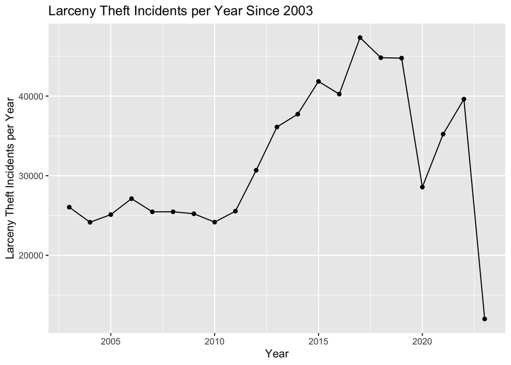

```r
counts_by_category_larceny <- counts_by_category %>%
  filter(Incident.Category == 'Larceny Theft')

# Overall Incidents over Time

ggplot(counts_by_category_larceny, aes(x= year, y= count_incidents)) +
  geom_point() +
  geom_line() +
  labs(x = 'Year', y = 'Larceny Theft Incidents per Year', title = 'Larceny Theft Incidents per Year Since 2003')
```

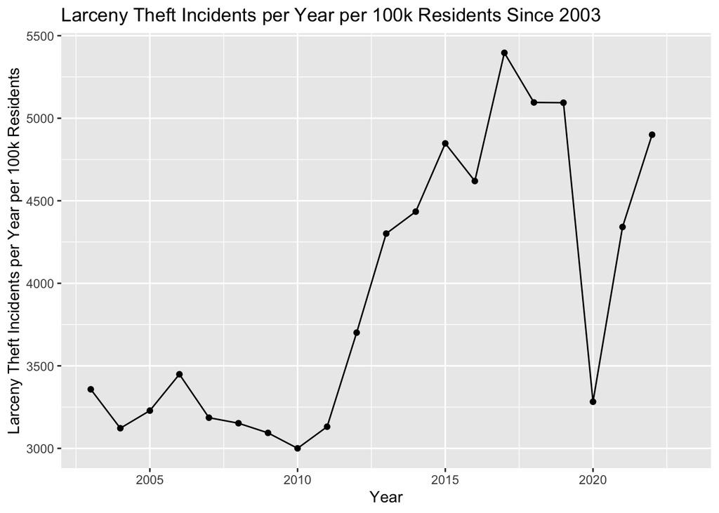

```r
# Incidents Per 100k

ggplot(counts_by_category_larceny, aes(x= year, y= incidents_per_100k)) +
  geom_point() +
  geom_line() +
  labs(x = 'Year', y = 'Larceny Theft Incidents per Year per 100k Residents', title = 'Larceny Theft Incidents per Year per 100k Residents Since 2003')
```

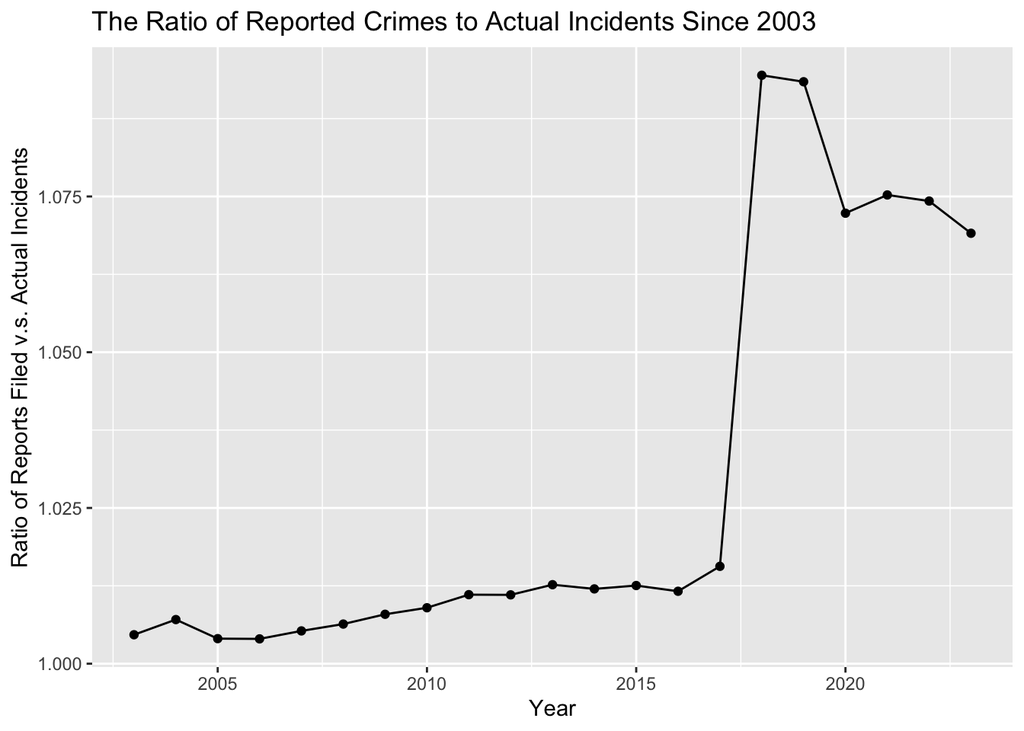

```r
# Ratio of Reports vs Actual Incidents

ggplot(counts_by_category_larceny, aes(x= year, y= ratio)) +
  geom_point() +
  geom_line() +
  labs(x = 'Year', y = 'Ratio of Reports Filed v.s. Actual Incidents', title = 'The Ratio of Reported Crimes to Actual Incidents Since 2003')
```

### Visualization: Rape

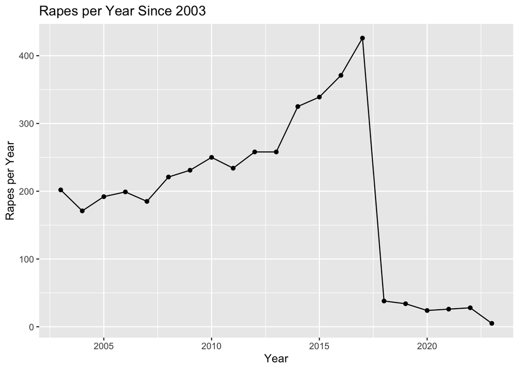

```r
counts_by_category_rape <- counts_by_category %>%
  filter(Incident.Category == 'Rape')

# Overall Incidents over Time

ggplot(counts_by_category_rape, aes(x= year, y= count_incidents)) +
  geom_point() +
  geom_line() +
  labs(x = 'Year', y = 'Rapes per Year', title = 'Rapes per Year Since 2003')
```

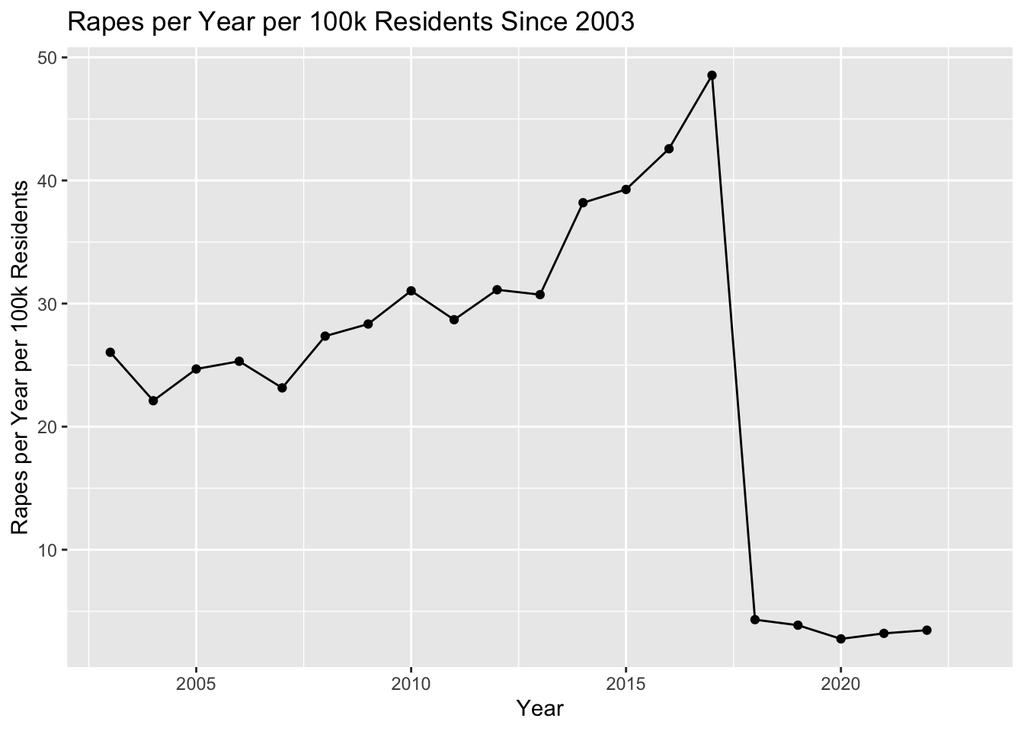

```r
# Incidents Per 100k

ggplot(counts_by_category_rape, aes(x= year, y= incidents_per_100k)) +
  geom_point() +
  geom_line() +
  labs(x = 'Year', y = 'Rapes per Year per 100k Residents', title = 'Rapes per Year per 100k Residents Since 2003')
```

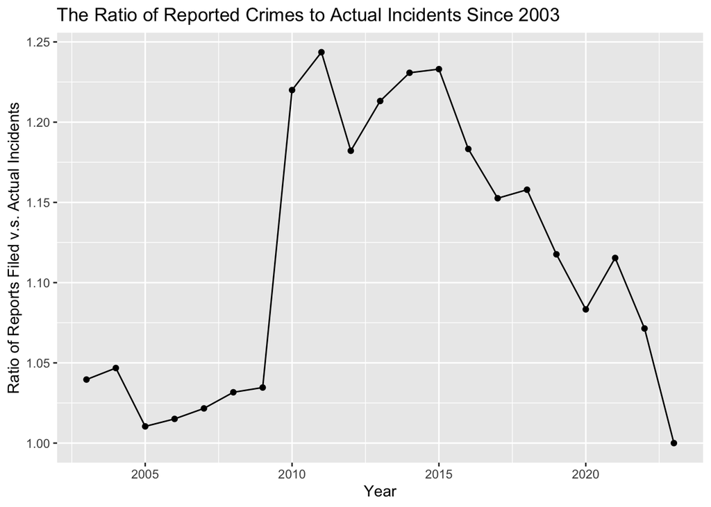

```r
# Ratio of Reports vs Actual Incidents

ggplot(counts_by_category_rape, aes(x= year, y= ratio)) +
  geom_point() +
  geom_line() +
  labs(x = 'Year', y = 'Ratio of Reports Filed v.s. Actual Incidents', title = 'The Ratio of Reported Crimes to Actual Incidents Since 2003')
```

### Assault

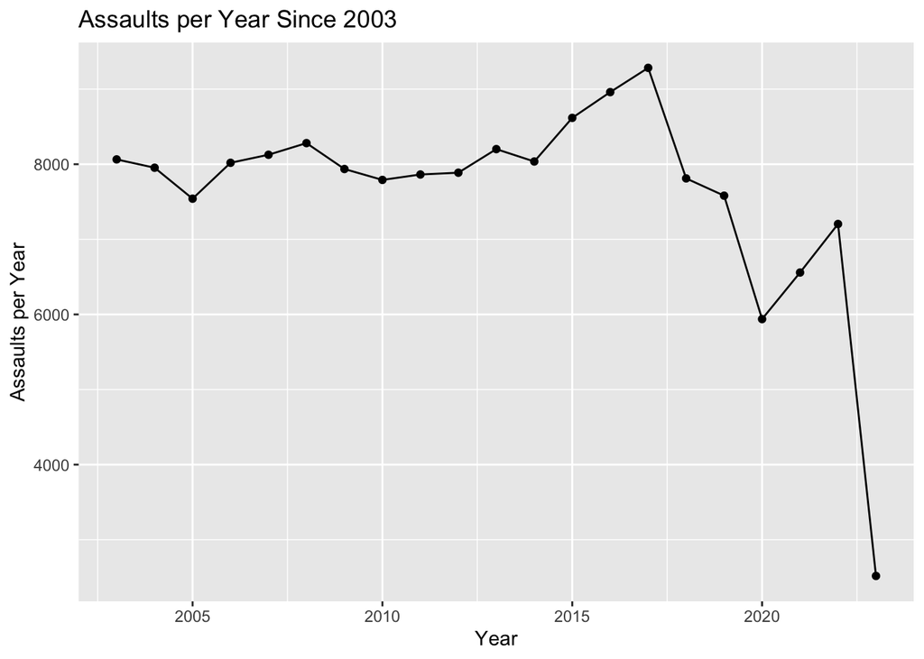

```r
counts_by_category_assault <- counts_by_category %>%
  filter(Incident.Category == 'Assault')

ggplot(counts_by_category_assault, aes(x= year, y= count_incidents)) +
  geom_point() +
  geom_line() +
  labs(x = 'Year', y = 'Assaults per Year', title = 'Assaults per Year Since 2003')
```

### Homicide

It is extremely hard to track homicide with DataSF and SFPD data. The data on homicide only goes back to 2018, not to mention and incident does not necessarily translate to a singular homicide and rather could translate to multiple homicides at one time. So, given the homicides are a rarer form of crime and the fact that one incident can actually mean multiple deaths sort of mystifies this already small set of results. Also, manslaughter is classified under the general homicide umbrella, likely necessitating a sub-category analysis on an already small category. I know accurate Homicide data exists under SFPD’s ownership, but it is not readily available to the public.

```r
counts_by_category_homicide <- counts_by_category %>%
  filter(Incident.Category == 'Homicide')

knitr::kable(counts_by_category_homicide)
```

| year | Population | Incident.Category | count_reports | count_incidents | ratio | incidents_per_100k |
| --- | --- | --- | --- | --- | --- | --- |
| 2018 | 879676 | Homicide | 24 | 15 | 1.600000 | 1.705173 |
| 2019 | 878826 | Homicide | 15 | 11 | 1.363636 | 1.251670 |
| 2020 | 870393 | Homicide | 12 | 11 | 1.090909 | 1.263797 |
| 2021 | 811253 | Homicide | 14 | 10 | 1.400000 | 1.232661 |
| 2022 | 808437 | Homicide | 29 | 24 | 1.208333 | 2.968691 |
| 2023 | NA | Homicide | 14 | 10 | 1.400000 | NA |

### SF City Budget

A continuation of this analysis could use this file that comes from DataSF detailing the cities budget over the years, with a specific focus on funding of the Police.

```r
budget <- read.csv('Budget.csv')
```

### Conclusion:

What is especially of note is that as crime per 100k residents, the reporting of crime increased. It is difficult to comment on exactly why that is because of lack of clearance rates and the inconsistency with the “Resolution” variable in both police incident report data sets.